# White Wines Quality Exploration by Sanjeev Yadav

This report explores a dataset containing quality and related chemical properties for 4898 white wines.

# Univariate Plots Section

```
## [1] 4898   12
```

```
## 'data.frame':    4898 obs. of  12 variables:
##  $ fixed.acidity       : num  7 6.3 8.1 7.2 7.2 8.1 6.2 7 6.3 8.1 ...
##  $ volatile.acidity    : num  0.27 0.3 0.28 0.23 0.23 0.28 0.32 0.27 0.3 0.22 ...
##  $ citric.acid         : num  0.36 0.34 0.4 0.32 0.32 0.4 0.16 0.36 0.34 0.43 ...
##  $ residual.sugar      : num  20.7 1.6 6.9 8.5 8.5 6.9 7 20.7 1.6 1.5 ...
##  $ chlorides           : num  0.045 0.049 0.05 0.058 0.058 0.05 0.045 0.045 0.049 0.044 ...
##  $ free.sulfur.dioxide : num  45 14 30 47 47 30 30 45 14 28 ...
##  $ total.sulfur.dioxide: num  170 132 97 186 186 97 136 170 132 129 ...
##  $ density             : num  1.001 0.994 0.995 0.996 0.996 ...
##  $ pH                  : num  3 3.3 3.26 3.19 3.19 3.26 3.18 3 3.3 3.22 ...
##  $ sulphates           : num  0.45 0.49 0.44 0.4 0.4 0.44 0.47 0.45 0.49 0.45 ...
##  $ alcohol             : num  8.8 9.5 10.1 9.9 9.9 10.1 9.6 8.8 9.5 11 ...
##  $ quality             : int  6 6 6 6 6 6 6 6 6 6 ...
```

```
##  fixed.acidity    volatile.acidity  citric.acid     residual.sugar
##  Min.   : 3.800   Min.   :0.0800   Min.   :0.0000   Min.   : 0.600
##  1st Qu.: 6.300   1st Qu.:0.2100   1st Qu.:0.2700   1st Qu.: 1.700
##  Median : 6.800   Median :0.2600   Median :0.3200   Median : 5.200
##  Mean   : 6.855   Mean   :0.2782   Mean   :0.3342   Mean   : 6.391
##  3rd Qu.: 7.300   3rd Qu.:0.3200   3rd Qu.:0.3900   3rd Qu.: 9.900
##  Max.   :14.200   Max.   :1.1000   Max.   :1.6600   Max.   :65.800
##    chlorides       free.sulfur.dioxide total.sulfur.dioxide
##  Min.   :0.00900   Min.   :  2.00      Min.   :  9.0
##  1st Qu.:0.03600   1st Qu.: 23.00      1st Qu.:108.0
##  Median :0.04300   Median : 34.00      Median :134.0
##  Mean   :0.04577   Mean   : 35.31      Mean   :138.4
##  3rd Qu.:0.05000   3rd Qu.: 46.00      3rd Qu.:167.0
##  Max.   :0.34600   Max.   :289.00      Max.   :440.0
##     density             pH          sulphates         alcohol
##  Min.   :0.9871   Min.   :2.720   Min.   :0.2200   Min.   : 8.00
##  1st Qu.:0.9917   1st Qu.:3.090   1st Qu.:0.4100   1st Qu.: 9.50
##  Median :0.9937   Median :3.180   Median :0.4700   Median :10.40
##  Mean   :0.9940   Mean   :3.188   Mean   :0.4898   Mean   :10.51
##  3rd Qu.:0.9961   3rd Qu.:3.280   3rd Qu.:0.5500   3rd Qu.:11.40
##  Max.   :1.0390   Max.   :3.820   Max.   :1.0800   Max.   :14.20
##     quality
##  Min.   :3.000
##  1st Qu.:5.000
##  Median :6.000
##  Mean   :5.878
##  3rd Qu.:6.000
##  Max.   :9.000
```

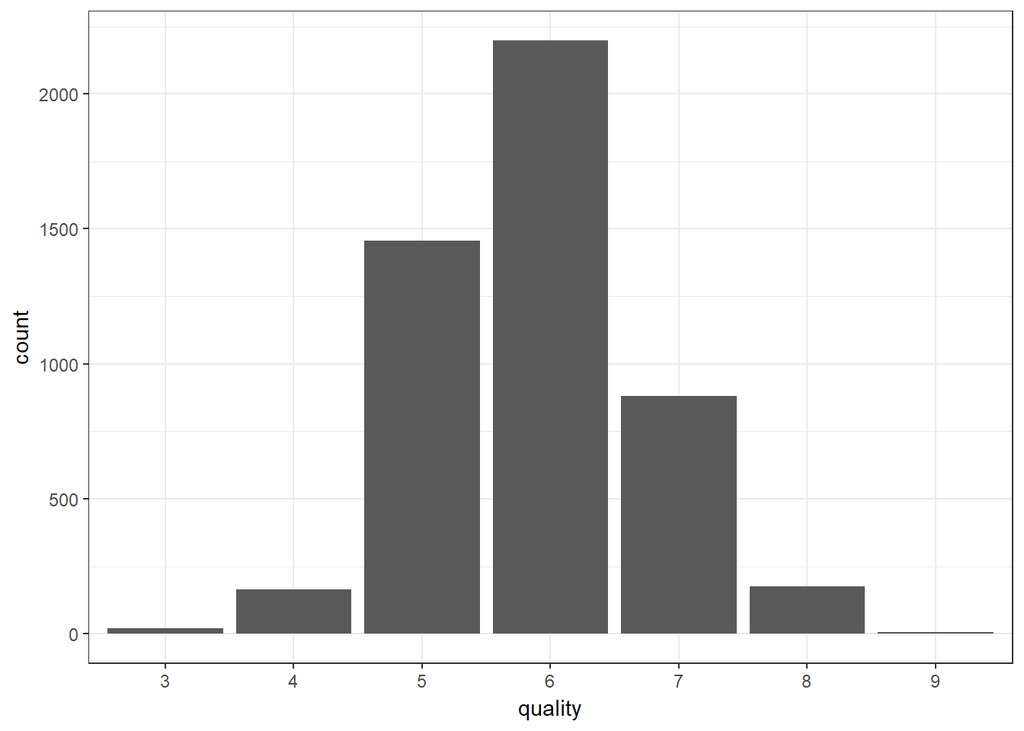

Quality distribution looks like a normal distribution with center at 6. Mode of the distribution is also 6.

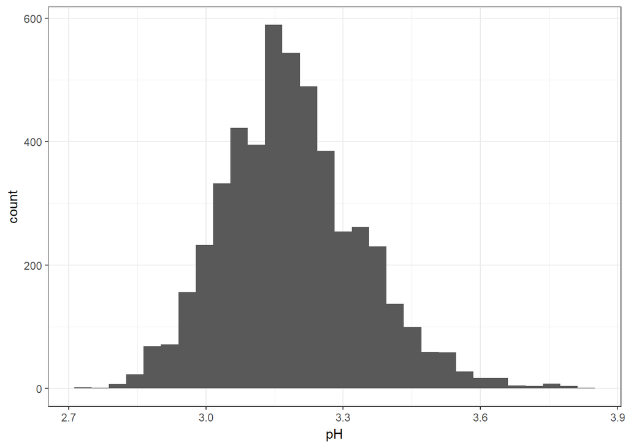

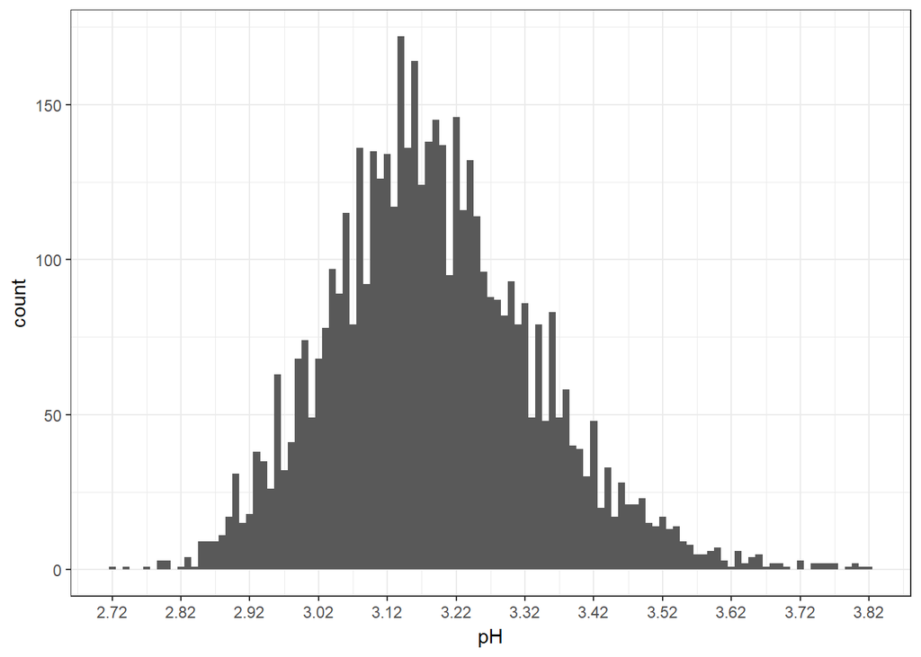

Distribution of pH is a normal distribution. Most of the wines are moderately acidic with peaks around 3.12.

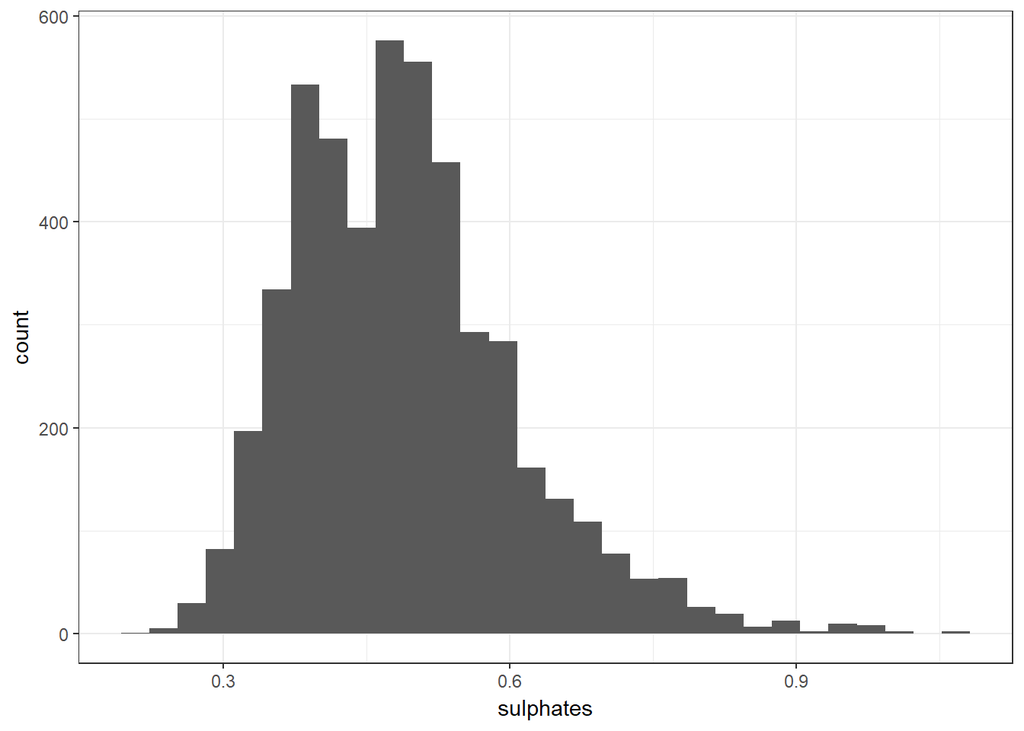

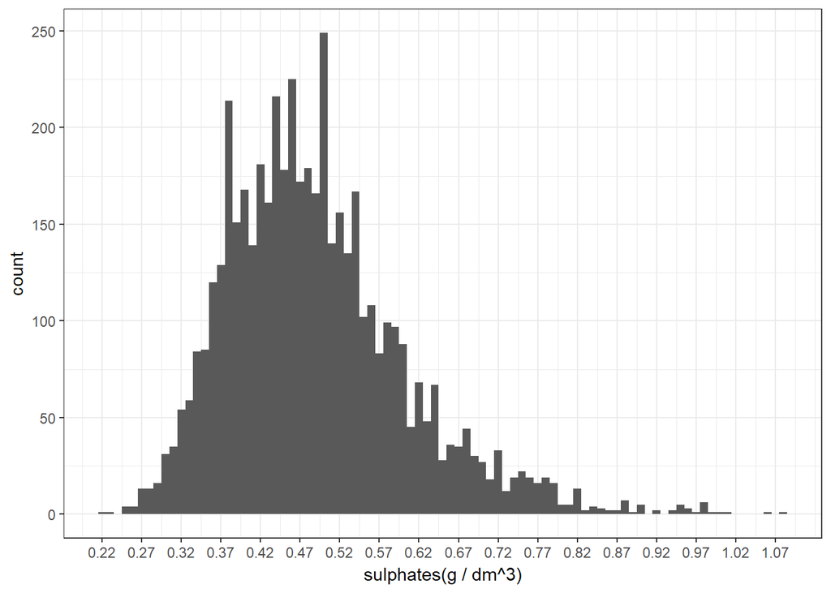

Distribution of sulphates is a right-skewed normal distribution, with most of the wines having sulphates around 0.45 g/dm^3.

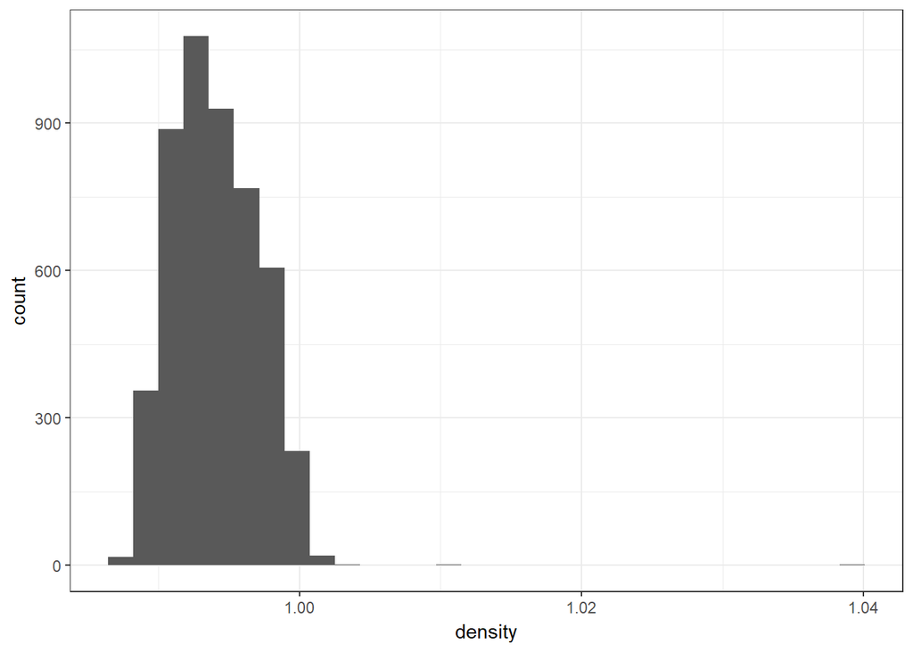

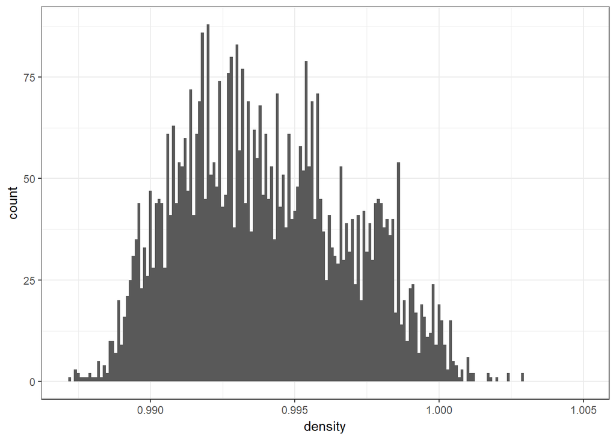

```
##    Min. 1st Qu.  Median    Mean 3rd Qu.    Max.
##  0.9871  0.9917  0.9937  0.9940  0.9961  1.0390
```

Density distribution is a normal distribution with mean = 0.994. There are some outlier above 1.01.

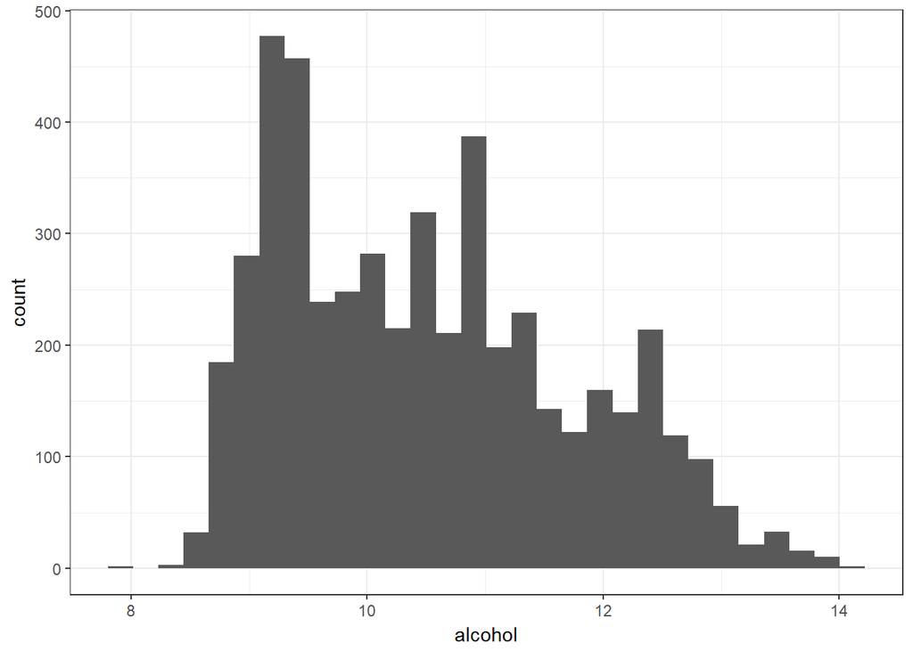

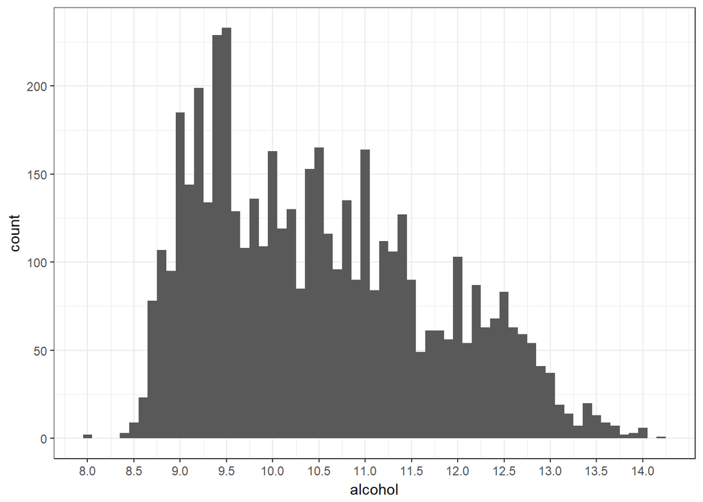

Distribution of alcohol content is right skewed. High alcohol content is harmful to health, this may be the reason why most of the wines have alcohol content around 9.5.

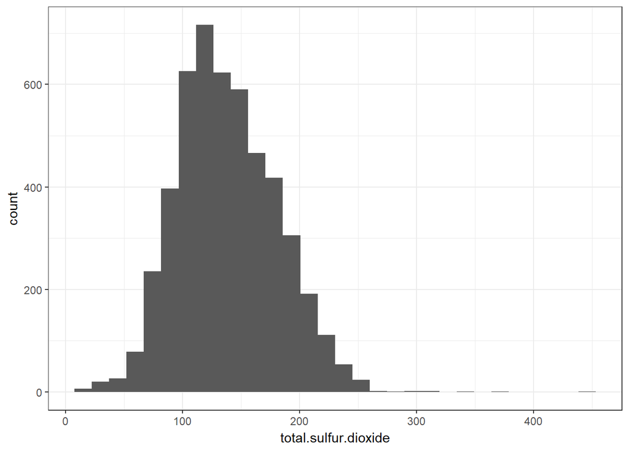

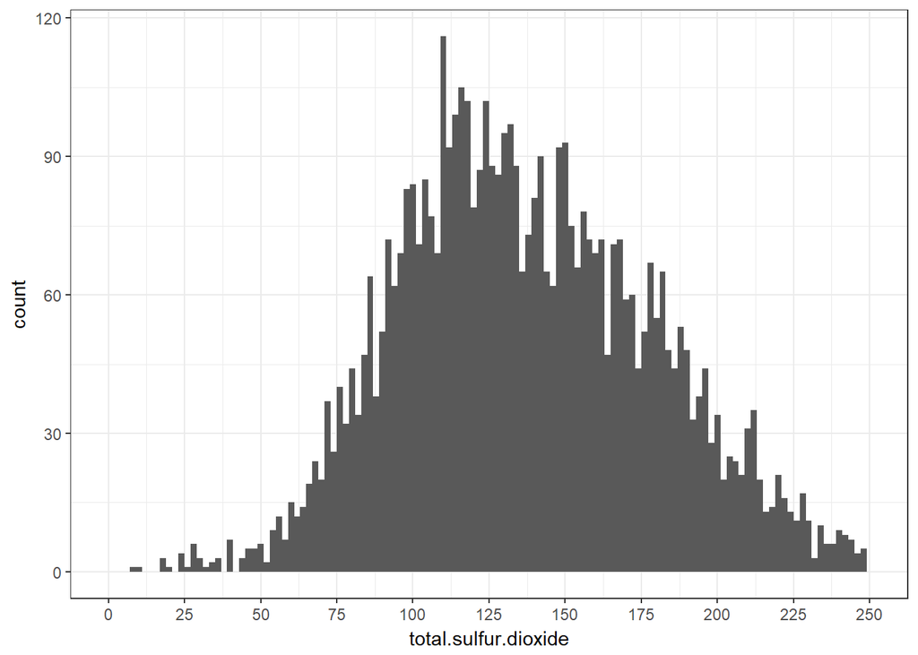

```
##    Min. 1st Qu.  Median    Mean 3rd Qu.    Max.
##     9.0   108.0   134.0   138.4   167.0   440.0
```

The total sulfur dioxide follow a normal distribution with mean at 138.4. There are some outliers above 250.

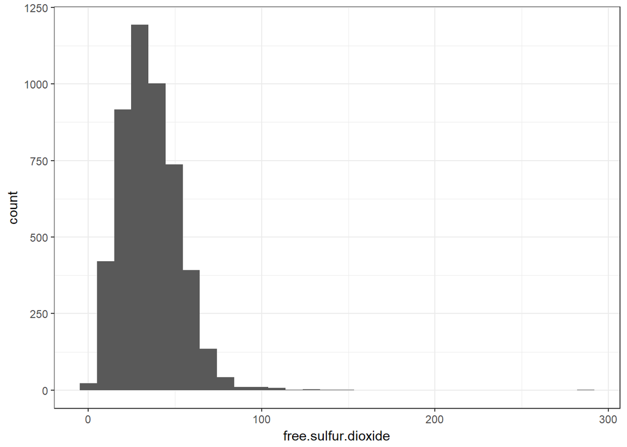

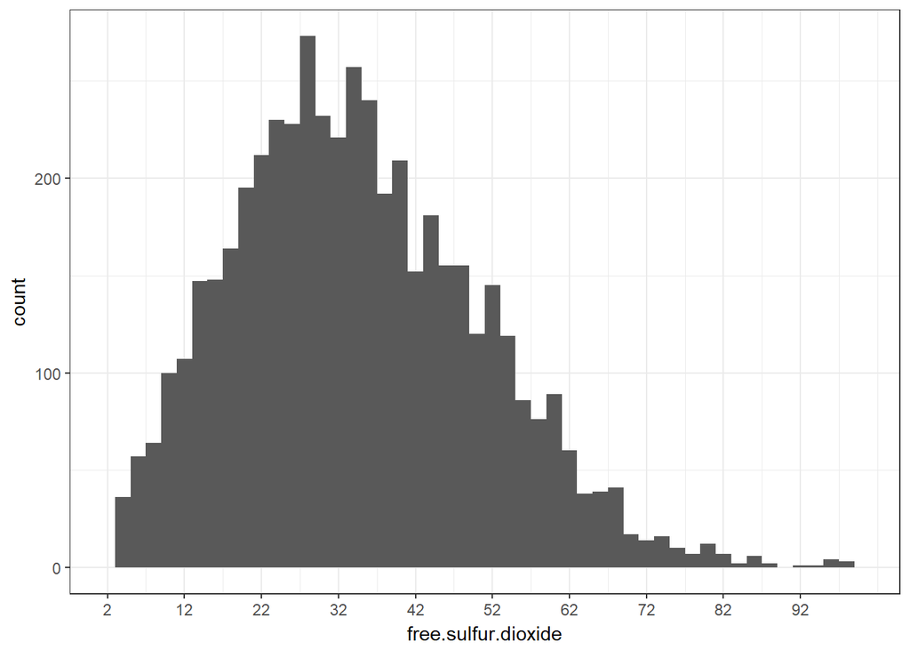

```
##    Min. 1st Qu.  Median    Mean 3rd Qu.    Max.
##    2.00   23.00   34.00   35.31   46.00  289.00
```

The free sulfur dioxide has a normal distribution with mean around 35.3 and some outlier above 100.

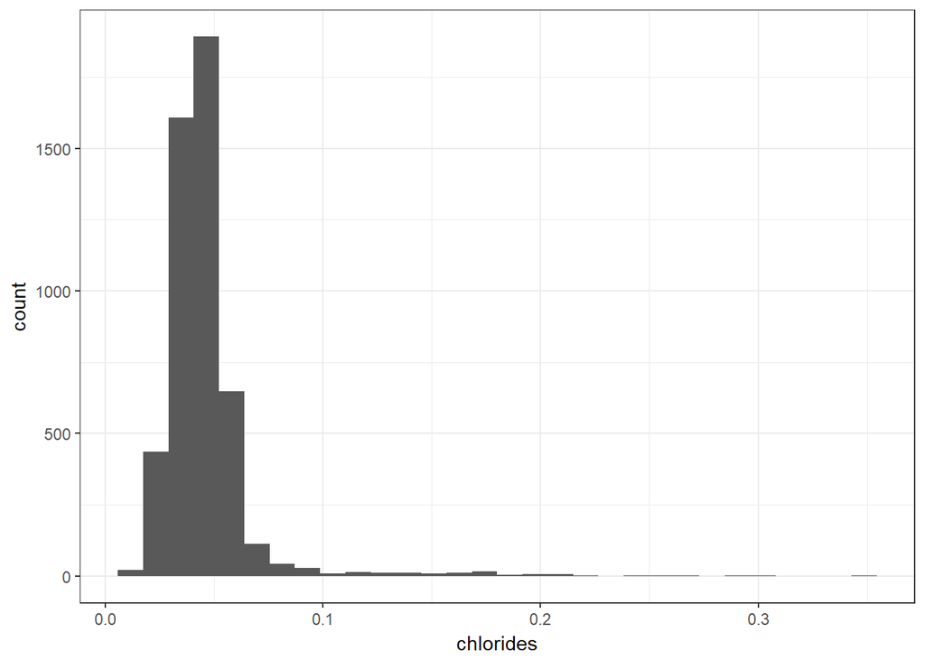

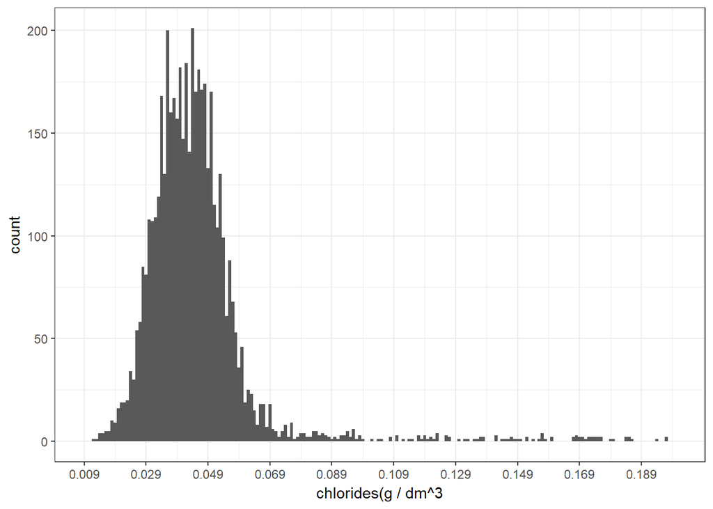

```
##    Min. 1st Qu.  Median    Mean 3rd Qu.    Max.
## 0.00900 0.03600 0.04300 0.04577 0.05000 0.34600
```

50% of the wines have chlorides between 0.036 and 0.05. The distribution is highly right skewed.

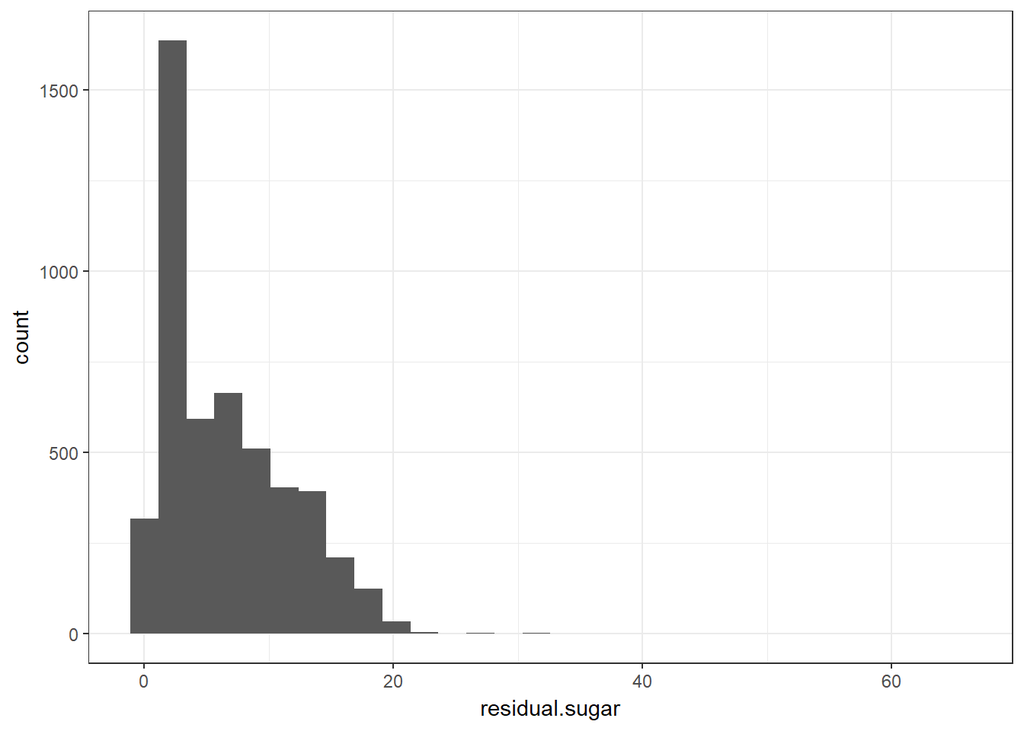

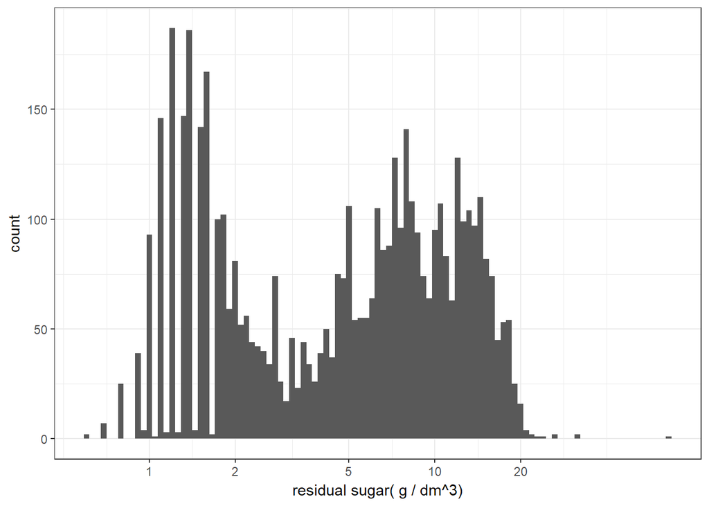

Using log scale to better understand the long tailed data. The transformed distribution of residual sugar looks bimodal with peaks around 1.5 and around 10.

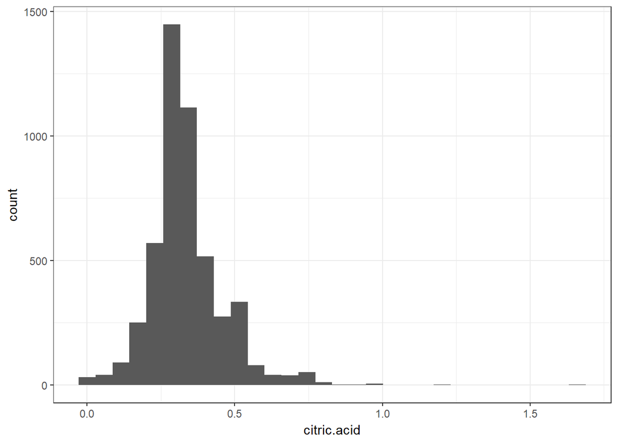

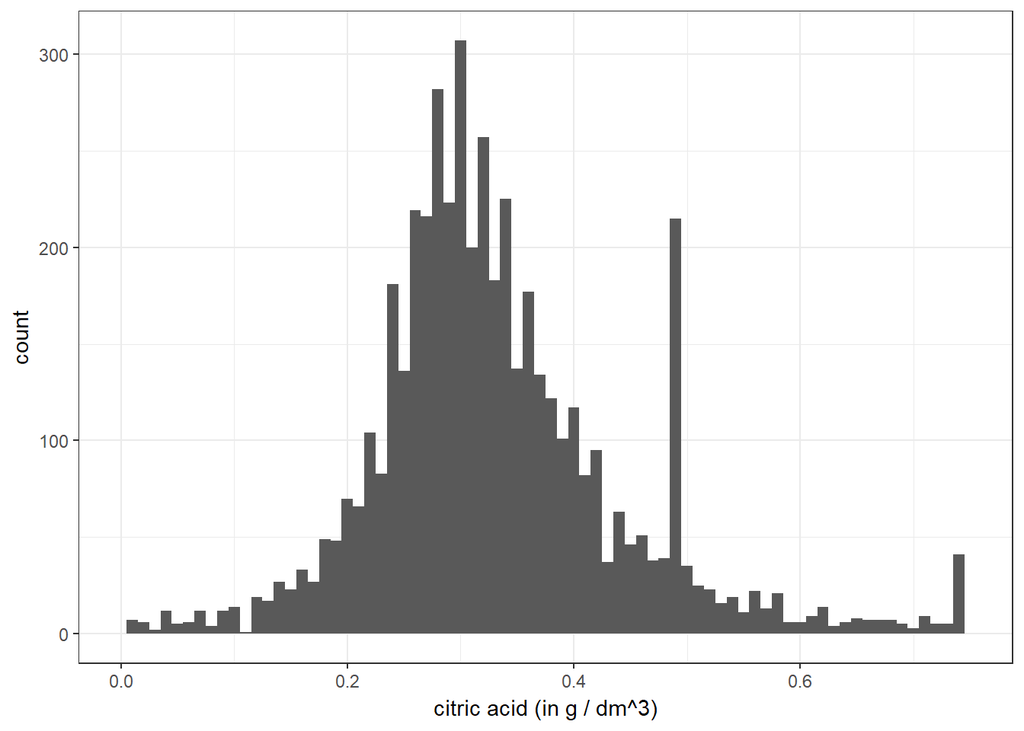

```
##    Min. 1st Qu.  Median    Mean 3rd Qu.    Max.
##  0.0000  0.2700  0.3200  0.3342  0.3900  1.6600
```

Citric acid follows a normal distribution with mean near 0.33 and some outliers above 0.75. Using binwidth = 0.01 shows that there is an unexpected peak around 0.5.

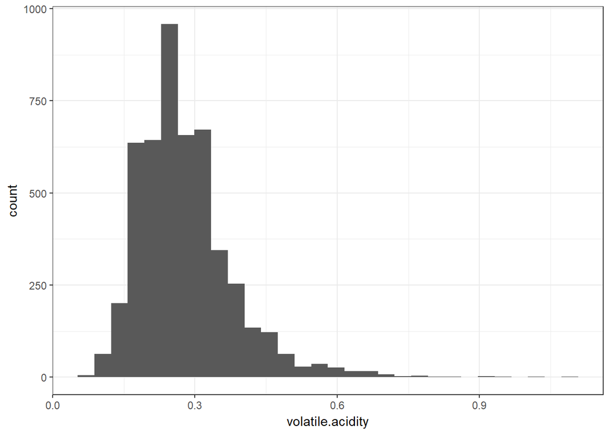

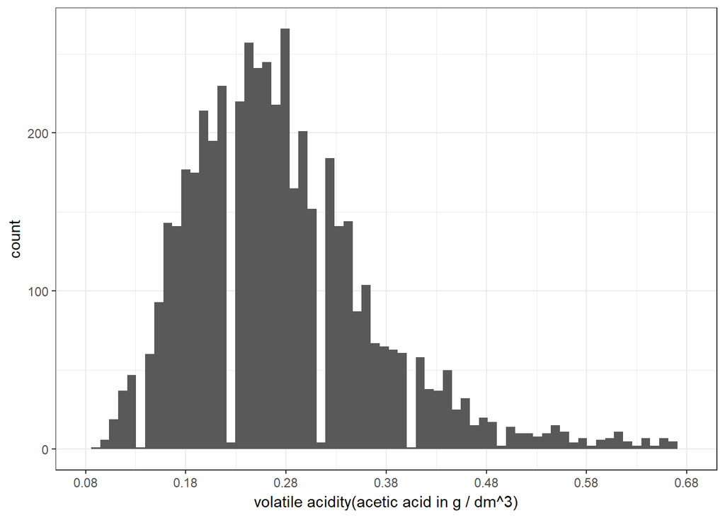

Volatile acidity follows a right-skewed normal distribution with with peaks around 0.28.

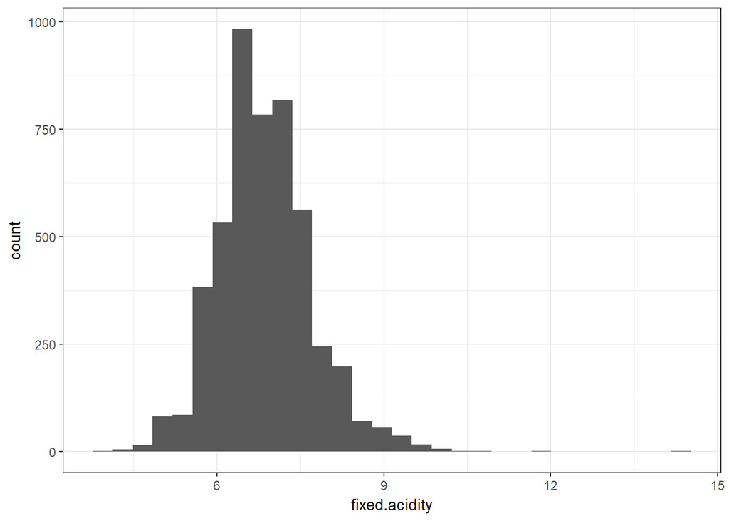

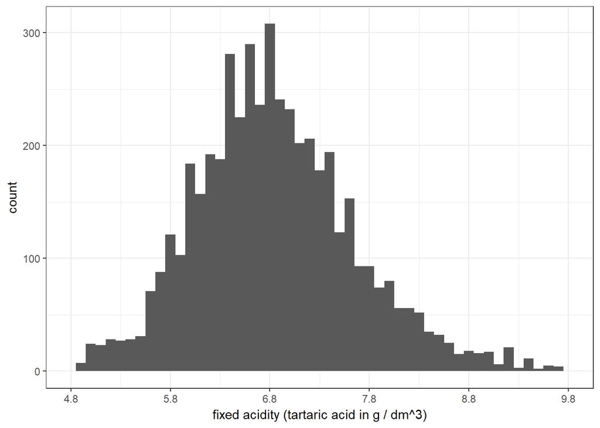

The fixed acidity has normal distribution with mean near 6.8 and some outliers above 9.8.

```r
w$total.acidity <- w$fixed.acidity + w$volatile.acidity + w$citric.acid
```

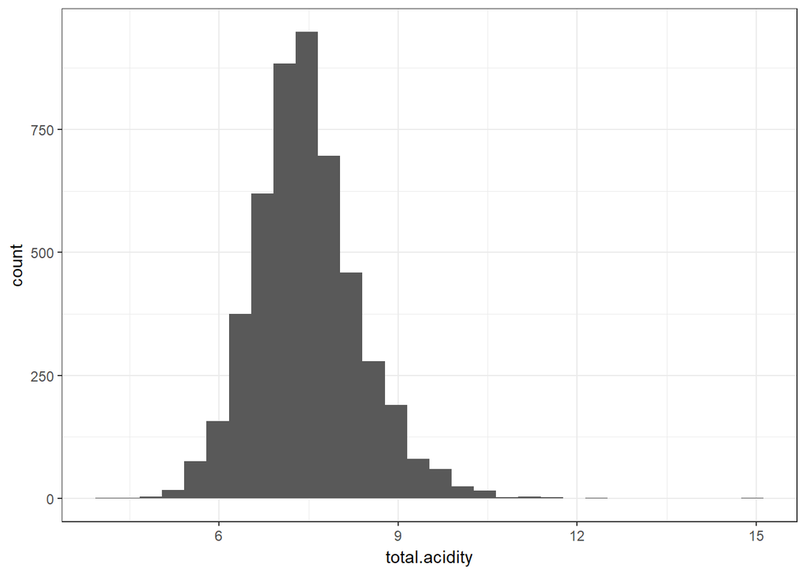

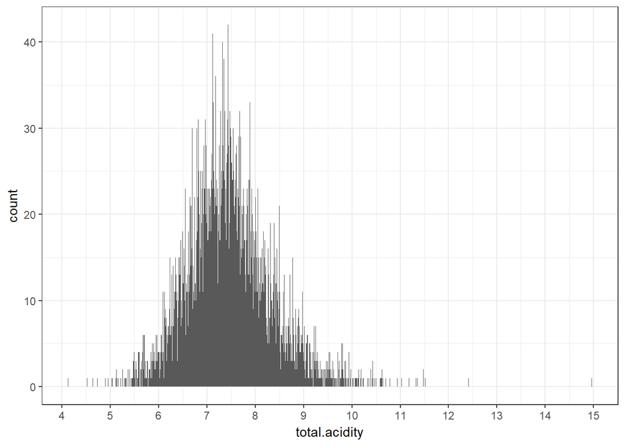

```
##    Min. 1st Qu.  Median    Mean 3rd Qu.    Max.
##   4.130   6.890   7.405   7.467   7.960  14.960
```

It will be helpful to see the relationship between total acidity and quality of wine.

# Univariate Analysis

### What is the structure of your dataset?

There are 4898 white wines with 12 features(fixed acidity, volatile acidity, citric acid, residual sugar, chlorides, free sulfur dioxide, total sulfur dioxide, density, pH, sulphates, alcohol and quality). At least 3 wine experts rated the quality of each wine, providing a rating between 0(very bad) and 10(very excellent). All the 11 chemical properties are numerical values of different ranges.

It will be helpful to treat quality variable as ordered categorical variable.

```r
w$quality.level <- ordered(w$quality, levels = c(3:9))
```

Other observations:

Most of the variables have normal distribution with some outliers.

### What is/are the main feature(s) of interest in your dataset?

The feature which we are trying to study is the quality of wine.Most of the wines have average quality rating. We will use the given chemical properties to predict the quality of wine.

### What other features in the dataset do you think will help support your investigation into your feature(s) of interest?

A good quality wine depends on the following factors: acid content and combined (sugar + alcohol) content. Other interesting features for this investigation can be: fixed.acidity, volatile.acidity, citric.acid, alcohol, residual.sugar and quality.

### Did you create any new variables from existing variables in the dataset?

Total acidity is the sum of the acids in this dataset. It included volatile acidity(acetic acid), fixed acidity(tartaric acid) and citric acid.

### Of the features you investigated, were there any unusual distributions? Did you perform any operations on the data to tidy, adjust, or change the form of the data? If so, why did you do this?

Residual sugar has the most unusual distribution. Using log10 scale on data shows that residual sugar had a bimodal distrrbution. Most of the other variables followed normal distribution, some of them were right skewed.

# Bivariate Plots Section

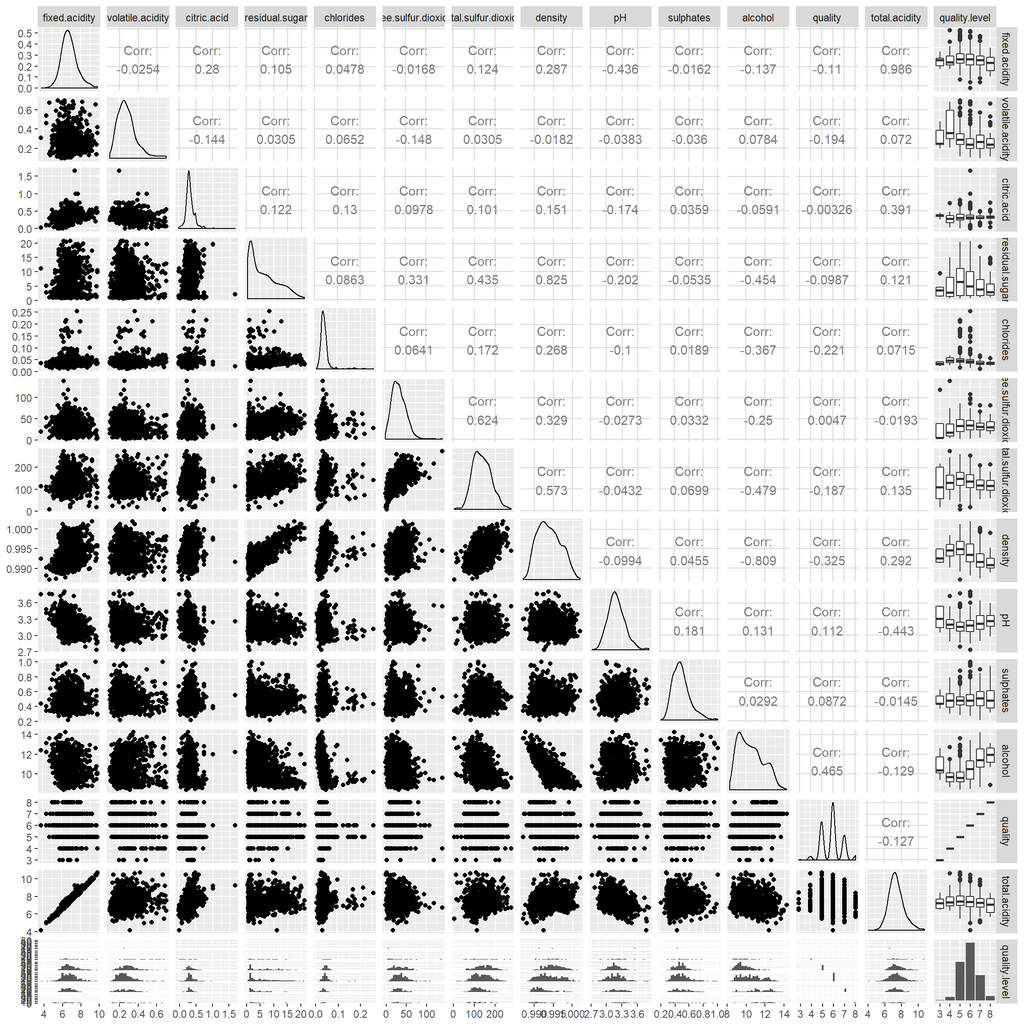

Density is strongly correlated with alcohol and residual sugar. This is an unexpected correlation. Lets see correlation matrix for only these features.

```
##                residual.sugar    density    alcohol     quality
## residual.sugar     1.00000000  0.8389665 -0.4506312 -0.09757683
## density            0.83896645  1.0000000 -0.7801376 -0.30712331
## alcohol           -0.45063122 -0.7801376  1.0000000  0.43557472
## quality           -0.09757683 -0.3071233  0.4355747  1.00000000
## total.acidity      0.10473749  0.2756088 -0.1175127 -0.13137721
##                total.acidity
## residual.sugar     0.1047375
## density            0.2756088
## alcohol           -0.1175127
## quality           -0.1313772
## total.acidity      1.0000000
```

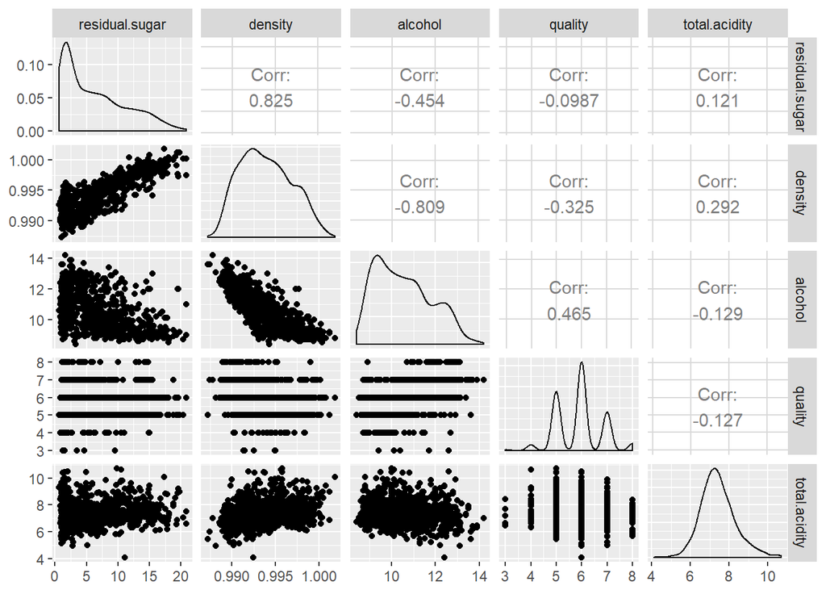

Lets see how these features are related with one another.

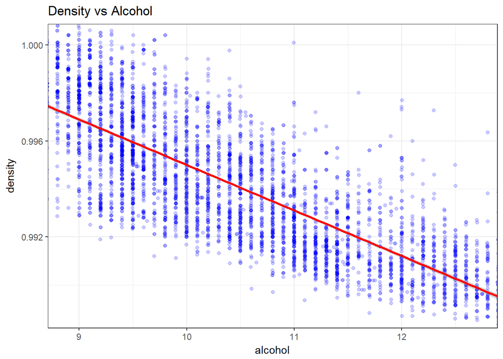

We can see a very strong correlation of -0.81 between the density and the alcohol content.

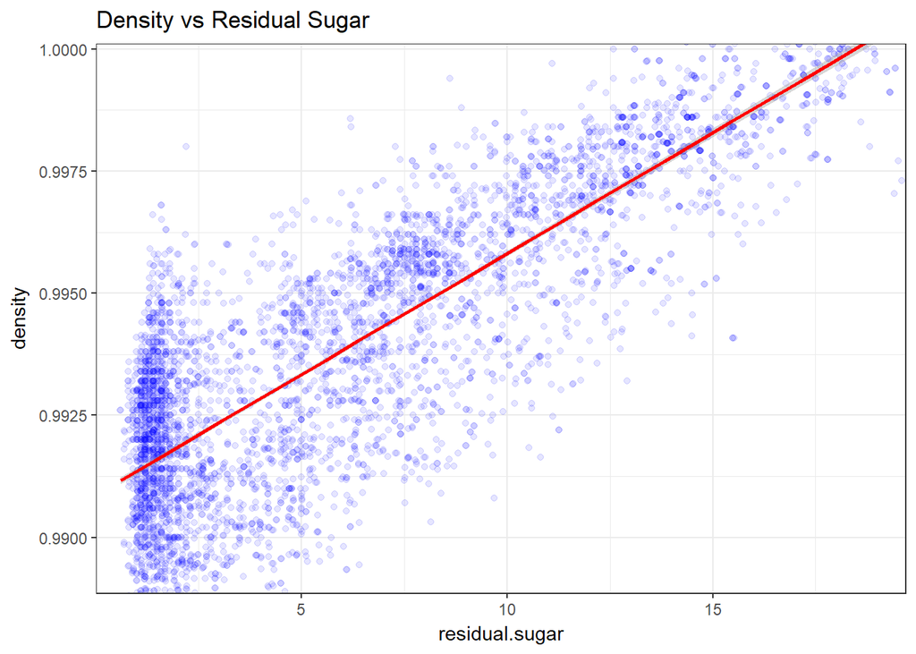

There is a very strong correlation of 0.83 between the residual sugar and the density of the wine.

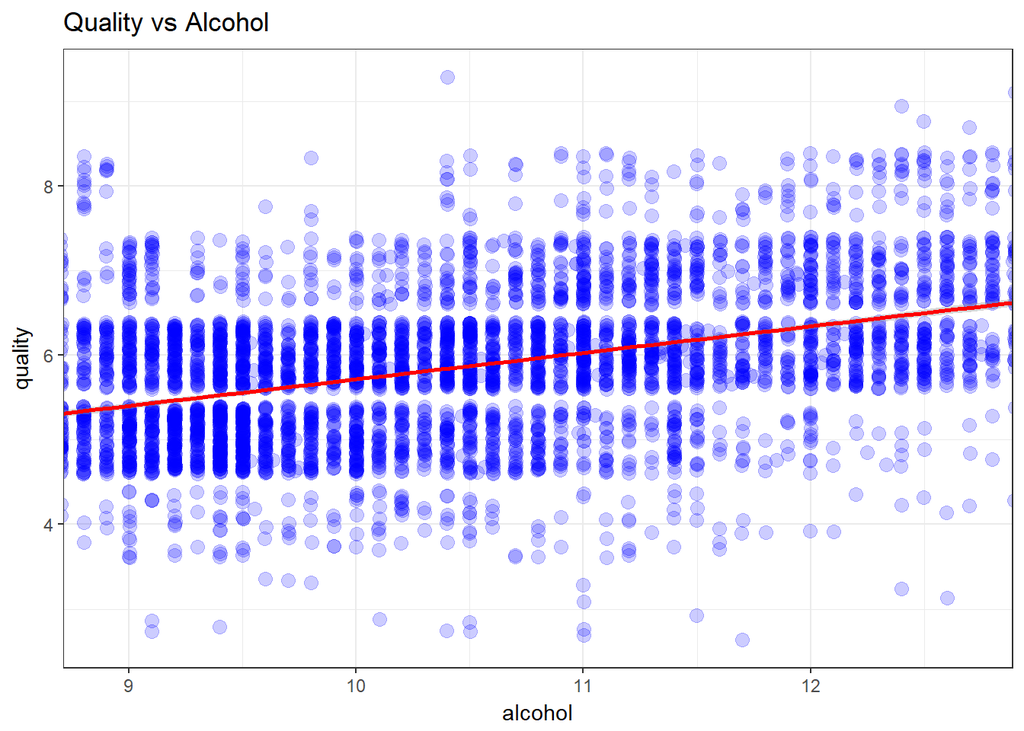

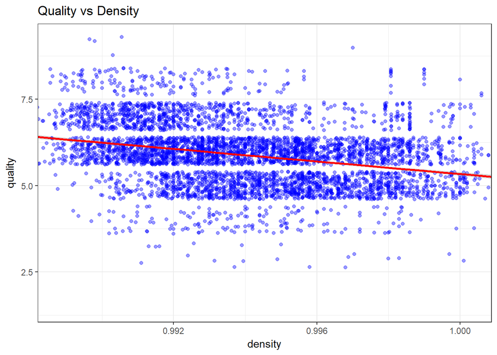

There is a weak but negative correlation between the quality and the density of the wine.

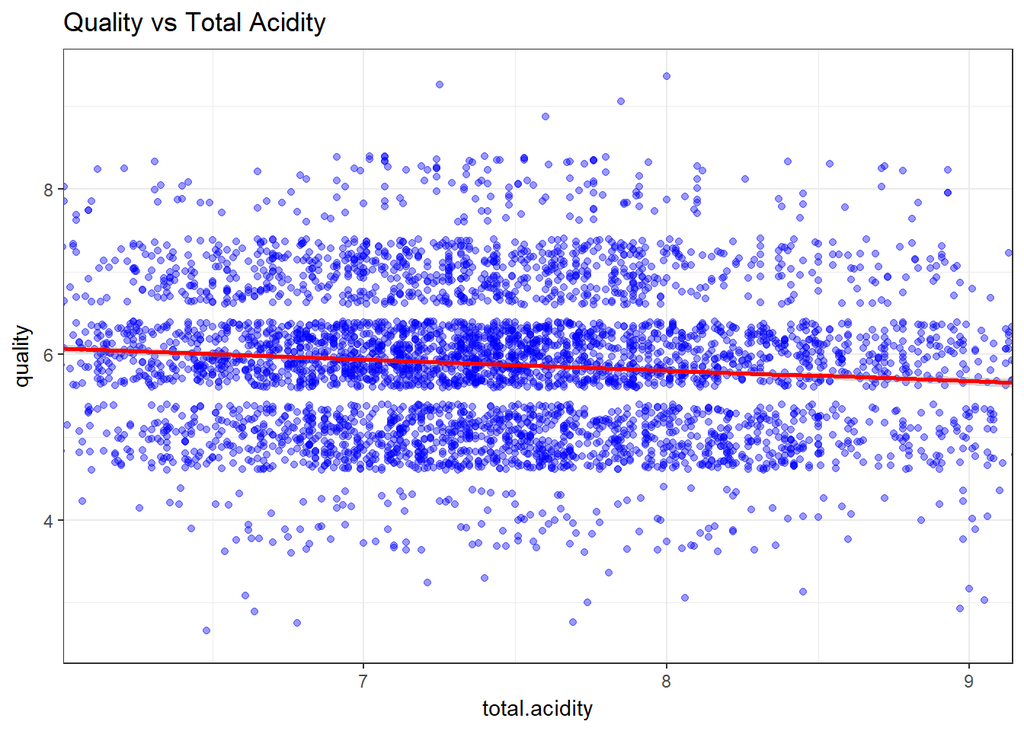

There is a weak correlation of -0.13 between quality and total acidity. The almost horizontal line shows that there is a weak dependence of total acidity on quality.